# Exercise 04

Jannik Buhr

05/11/2021

# Preparation

```r
library(tidyverse)
```

# Exercises

Source: https://jmbuhr.de/dataintro/tidy-data.html#exercises-2

## Tidy Data from R for Data Science

### 1.

```r
stocks <- tibble(
  year   = c(2015, 2015, 2016, 2016),
  half  = c(   1,    2,     1,    2),
  return = c(1.88, 0.59, 0.92, 0.17)
)
stocks %>%
  pivot_wider(names_from = year, values_from = return) %>%
  pivot_longer(`2015`:`2016`, names_to = "year", values_to = "return",
               # names_ptypes = list(year = double()),
               names_transform = list(year = as.double))
```

| half | year | return |
| --- | --- | --- |
| 1 | 2015 | 1.88 |
| 1 | 2016 | 0.92 |
| 2 | 2015 | 0.59 |
| 2 | 2016 | 0.17 |

In the seminar we talked about why `pivot_longer` and `pivot_wider` are not perfectly symmetrical i.e. don’t invert each other. One of the main reason is that column names have to conform to the same standards that variable names have to conform to, so when we take column names and put them as data into a column they will start out as being text text data (a character vector). We can work around this with the `names_transform` argument.

### 2.

Without the backticks, R will look for the columns with the index 1999 and 2000 instead of columns with the names 1999 and 2000. The backticks allow us to use “forbidden” variable and column names such as those starting with a number.

```r
table4a %>%
  pivot_longer(c(`1999`, `2000`), names_to = "year", values_to = "cases")
```

| country | year | cases |
| --- | --- | --- |
| Afghanistan | 1999 | 745 |
| Afghanistan | 2000 | 2666 |
| Brazil | 1999 | 37737 |
| Brazil | 2000 | 80488 |
| China | 1999 | 212258 |
| China | 2000 | 213766 |

### 3.

```r
people <- tribble(
  ~name,             ~names,  ~values,
  #-----------------|--------|------
  "Phillip Woods",   "age",       45,
  "Phillip Woods",   "height",   186,
  "Phillip Woods",   "age",       50,
  "Jessica Cordero", "age",       37,
  "Jessica Cordero", "height",   156
)

people %>%
  group_by(name, names) %>%
  mutate(id = 1:n()) %>%
  pivot_wider(names_from = names, values_from = values)
```

| name | id | age | height |
| --- | --- | --- | --- |
| Phillip Woods | 1 | 45 | 186 |
| Phillip Woods | 2 | 50 | NA |
| Jessica Cordero | 1 | 37 | 156 |

### 4.

```r
preg <- tribble(
  ~pregnant, ~male, ~female,
  "yes",     NA,    10,
  "no",      20,    12
)

preg %>%
  pivot_longer(c(male, female), names_to = "sex", values_to = "count")
```

| pregnant | sex | count |
| --- | --- | --- |
| yes | male | NA |
| yes | female | 10 |
| no | male | 20 |
| no | female | 12 |

Remember that “tidy” data does not mean that all other formats are “messy”, it is just a way of organizing our data such that every column is a feature and every row corresponds to a set of observations of the features. This allows us to work with it nicely in the tidyverse, especially with `dplyr` and `ggplot2`.

## A new dataset: airlines

> Imagine for a second this whole pandemic thing is not going on and we are planning a vacation. Of course, we want to choose the safest airline possible. So we download data about incident reports. You can find it in the `./data/03/` folder.

> Instead of the `type_of_event` and `n_events` columns we would like to have one column per type of event, where the values are the count for this event.

```r
airlines <- read_csv("data/03/airlines.csv") %>%
  pivot_wider(names_from = type_of_event,
              values_from = n_events)

airlines
```

| airline | avail_seat_km_per_week | year_range | incidents | fatal_accidents | fatalities |
| --- | --- | --- | --- | --- | --- |
| Aer Lingus | 320906734 | 85_99 | 2 | 0 | 0 |
| Aeroflot* | 1197672318 | 85_99 | 76 | 14 | 128 |
| Aerolineas Argentinas | 385803648 | 85_99 | 6 | 0 | 0 |
| Aeromexico* | 596871813 | 85_99 | 3 | 1 | 64 |
| Air Canada | 1865253802 | 85_99 | 2 | 0 | 0 |
| Air France | 3004002661 | 85_99 | 14 | 4 | 79 |
| Air India* | 869253552 | 85_99 | 2 | 1 | 329 |
| Air New Zealand* | 710174817 | 85_99 | 3 | 0 | 0 |
| Alaska Airlines* | 965346773 | 85_99 | 5 | 0 | 0 |
| Alitalia | 698012498 | 85_99 | 7 | 2 | 50 |

[output cut: 102 more lines]

```r
airlines <- airlines %>%
  select(-year_range) %>%
  group_by(airline) %>%
  summarise(
    across(everything(), sum)
  )
```

> Which airlines had the least fatal accidents? What happens if we standardized these numbers to the distance theses airlines covered in the two time ranges?

```r
airlines %>%
  arrange(fatal_accidents, desc(avail_seat_km_per_week))
```

| airline | avail_seat_km_per_week | incidents | fatal_accidents | fatalities |
| --- | --- | --- | --- | --- |
| Southwest Airlines | 6553051540 | 9 | 0 | 0 |
| British Airways* | 6359521904 | 10 | 0 | 0 |
| Cathay Pacific* | 5164918606 | 2 | 0 | 0 |
| Qantas* | 3834857968 | 6 | 0 | 0 |
| Air Canada | 3730507604 | 4 | 0 | 0 |
| Virgin Atlantic | 2010497170 | 1 | 0 | 0 |
| TAP - Air Portugal | 1238261508 | 0 | 0 | 0 |
| Finnair | 1012929900 | 1 | 0 | 0 |
| Hawaiian Airlines | 987755590 | 1 | 0 | 0 |
| Aerolineas Argentinas | 771607296 | 7 | 0 | 0 |

[output cut: 46 more lines]

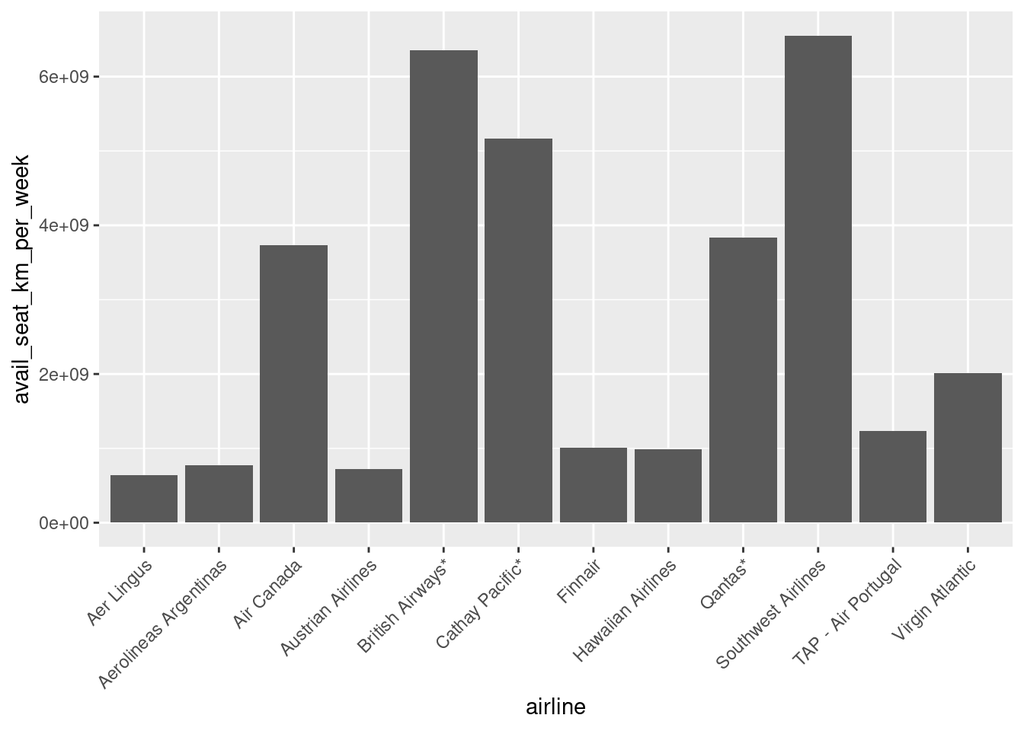

```r
airlines %>%
  filter(fatal_accidents == 0) %>%
  ggplot(aes(airline, avail_seat_km_per_week)) +
  geom_col() +
  theme(axis.text.x = element_text(angle = 45, hjust = 1))
```

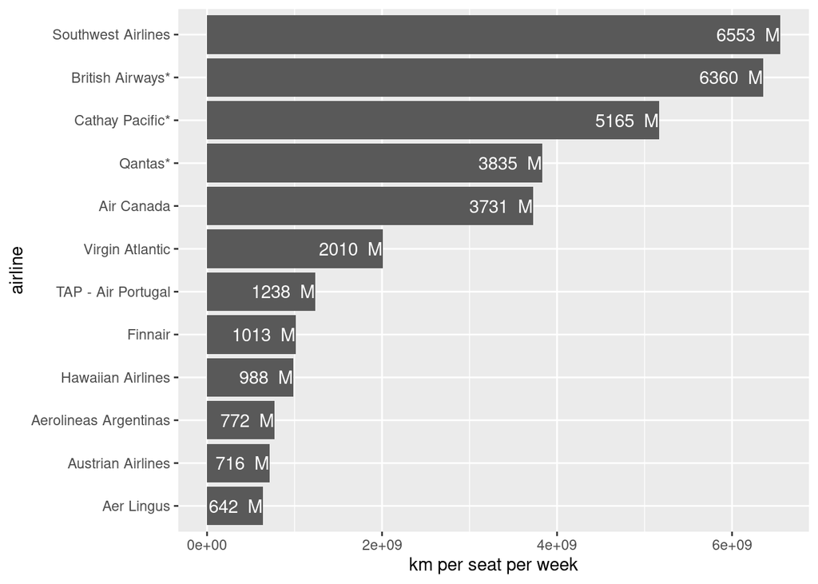

```r
airlines %>%
  filter(fatal_accidents == 0) %>%
  mutate(airline = fct_reorder(airline, avail_seat_km_per_week),
         km = paste(round(avail_seat_km_per_week / 1e6), " M")) %>%
  ggplot(aes(airline, avail_seat_km_per_week)) +
  geom_col() +
  geom_text(aes(label = km), hjust = 1, color = "white") +
  coord_flip() +
  labs(y = "km per seat per week")
```

> Which airlines have the best record when it comes to fatalities per fatal accident?

```r
airlines %>%
  filter(fatal_accidents != 0) %>%
  mutate(fatalities_per_accident = fatalities / fatal_accidents) %>%
  arrange(fatalities_per_accident) %>%
  select(airline, fatalities_per_accident, everything())
```

| airline | fatalities_per_accident | avail_seat_km_per_week | incidents | fatal_accidents | fatalities |
| --- | --- | --- | --- | --- | --- |
| All Nippon Airways | 1.00000 | 3682468354 | 10 | 1 | 1 |
| Lufthansa* | 2.00000 | 6853059008 | 9 | 1 | 2 |
| KLM* | 3.00000 | 3749123546 | 8 | 1 | 3 |
| TACA | 3.00000 | 518746692 | 4 | 2 | 6 |
| El Al | 4.00000 | 670896046 | 2 | 1 | 4 |
| Air New Zealand* | 7.00000 | 1420349634 | 8 | 1 | 7 |
| LAN Airlines | 10.50000 | 2003931782 | 3 | 2 | 21 |
| Sri Lankan / AirLanka | 14.00000 | 651165952 | 6 | 1 | 14 |
| Aeroflot* | 14.40000 | 2395344636 | 82 | 15 | 216 |
| Philippine Airlines | 15.00000 | 826014316 | 9 | 5 | 75 |

[output cut: 34 more lines]